# General introduction to the hdp package

Nicola Roberts

2015-10-05

Model categorical count data with a Hierarchical Dirichlet Process as described by Teh et al. (Hierarchical Dirichlet Processes, Journal of the American Statistical Association, 2006, 101:476). This R package was adapted from [open source MATLAB and C code](http://www.stats.ox.ac.uk/~teh/research/npbayes/npbayes-r21.tgz) written by Yee Whye Teh.

```r
library(hdp)
```

# Terminology and method overview

The input data consists of counts of **data items** in each data **category** for each **sample**. The HDP model assumes the data is drawn from a mixture of underlying categorical distributions that are shared (in different mixture ratios) across samples.

The user defines a tree-like structure for the HDP, wherein each DP **node** draws a mixture of categorical data distributions from its parent node. Data is assigned to particular DP nodes (usually one sample per leaf node), and the structure of the parent DP nodes defines hierarchies of sample-relatedness given some prior knowledge of sample groups.

In each iteration of the posterior sampling process, every data item is assigned to a raw **cluster**. After posterior sampling, raw clusters are grouped into **components**. Unlike the raw clusters, the components won’t be “too small” (a raw cluster could contain just one data item) nor “too similar” (the distribution of categories in two raw clusters could be about the same, but these raw clusters would then be grouped into one component), and there will be the same number of components across all posterior samples (the number of raw clusters varies across posterior samples). After grouping the raw clusters into global components, any data item that is not assigned to a main component is assigned to **component zero**. This “zero” component contains the proportion of the dataset with uncertain clustering behaviour, possibly due to noise.

# Toy dataset

To illustrate the basic features of the *hdp* package, we consider a toy dataset of categorical count data with **10 samples** (rows) and **6 categories** (columns). The counts were simulated from two underlying categorical distributions with a different average mixture ratio in the first and last set of five samples.

```r
example_data_hdp
```

```
##       [,1] [,2] [,3] [,4] [,5] [,6]
##  [1,]  130   59   86  158   84   81
##  [2,]    7    6    6   30   10   12
##  [3,]    5    8    7   15    6    8
##  [4,]    6    1   10   10    7    6
##  [5,]   76   27   40   63   39   39
##  [6,]   11    1    4    6    2    1
##  [7,]   17   14   25   44   19   10
##  [8,]   31   11   16   20   22   10
##  [9,]   13    1    7   11    4    6
## [10,]   49   16   16   19    7   13
```

# Quick start with basic HDP structure

## Initialise hdpState object via hdp_quick_init

Use `hdp_quick_init()` to initialise a basic default HDP structure with one top parent DP node with no associated data, and one child DP node per sample. Every DP node shares the same concentration parameter, and will automatically be ‘activated’ (made available for posterior sampling). The base distribution is a uniform Dirichlet with psuedocount 1 in each data category.

```r
set.seed(10)
quick_hdp <- hdp_quick_init(example_data_hdp)
quick_hdp
```

```
## Object of class hdpState
##  Number of DP nodes: 11
##  Index of parent DP: 0 1 1 1 1 1 1 1 1 1 ...
##  Number of data items per DP: 0 598 71 49 40 284 25 129 110 42 ...
##  Index of conparam per DP: 1 1 1 1 1 1 1 1 1 1 ...
##  Conparam hyperparameters and current value:
##            Shape Rate Value
## Conparam 1     1    1     1
##  Number of data categories: 6
##  Number of clusters: 2
##  Initialised with 2 clusters, using random seed 5074783
```

`hdp_quick_init()` returns a `hdpState` object. Notice that it has 11 DP nodes (one parent, and one for each of 10 samples), and that the index of the parent node is 0 for the first DP (the parent is the top node) and 1 for the others. The first DP node (the parent) has no associated data items, while the second DP node has 598 (first sample), the third has 71 (second sample) and so on. With the default settings, the number of initial clusters is 2, and the hyperparameters for the concentration parameter are both 1.

Note that initialising clusters is random, and so the seed is reported for reproducibility. *However*, `hdp_quick_init()` does not let the user set a seed, so for reproducible results the seed can be set before running `hdp_quick_init()` *or* the HDP can be defined manually (see below) and the seed set via `dp_activate()`.

## Run posterior sampling chain

The output of `hdp_quick_init()` is ready for posterior sampling via `hdp_posterior()`. The user must specify the number of burn-in iterations, the number of posterior samples to collect, and the number of iterations between each collected sample. Each iteration re-assigns the cluster allocation of every data item, given the current allocations of all other data items.

```r
quick_chain <- hdp_posterior(quick_hdp, burnin=100, n=100, space=10, seed=1234)
```

```
## [1] "100 burn-in iterations in 0.0 mins"
```

```r
quick_chain
```

```
## Object of class hdpSampleChain
##  Random seed: 1234
##  Burn-in iters: 100
##  Posterior samples: 100
##  Iters b/w samples: 10
##  Conparam moves per iter: 1
##  Tabulate raw cluster number across samples:
##  2  3  4  5  6  7  8  9 10
##  6 17 17 23 21  8  4  2  2
##  Components: NO. Run hdp_extract_components
##  ----------
##  Final hdpState:
## Object of class hdpState
##  Number of DP nodes: 11
##  Index of parent DP: 0 1 1 1 1 1 1 1 1 1 ...
##  Number of data items per DP: 0 598 71 49 40 284 25 129 110 42 ...
##  Index of conparam per DP: 1 1 1 1 1 1 1 1 1 1 ...
##  Conparam hyperparameters and current value:
##            Shape Rate     Value
## Conparam 1     1    1 0.9198171
##  Number of data categories: 6
##  Number of clusters: 5
##  Initialised with 2 clusters, using random seed 5074783
```

`hdp_posterior()` returns a `hdpSampleChain` object. Notice that the number of raw clusters varies across the 100 posterior samples collected off the chain.

## Assess quality of posterior sampling chain

Theoretically, an infinitely long posterior sampling chain would sample all possible cluster models in proportion to their likelihood. In practice, we aim to have a finite posterior sample set that approximates the true infinite random sampling space.

To assess the choice of burn-in time and number of iterations between collected samples, consider the following set of diagnostic plots (ideally, want no strong trends across posterior samples).

Note that the best approximation of the infinite random sampling space is achieved with multiple independent sampling chains (described in a later section).

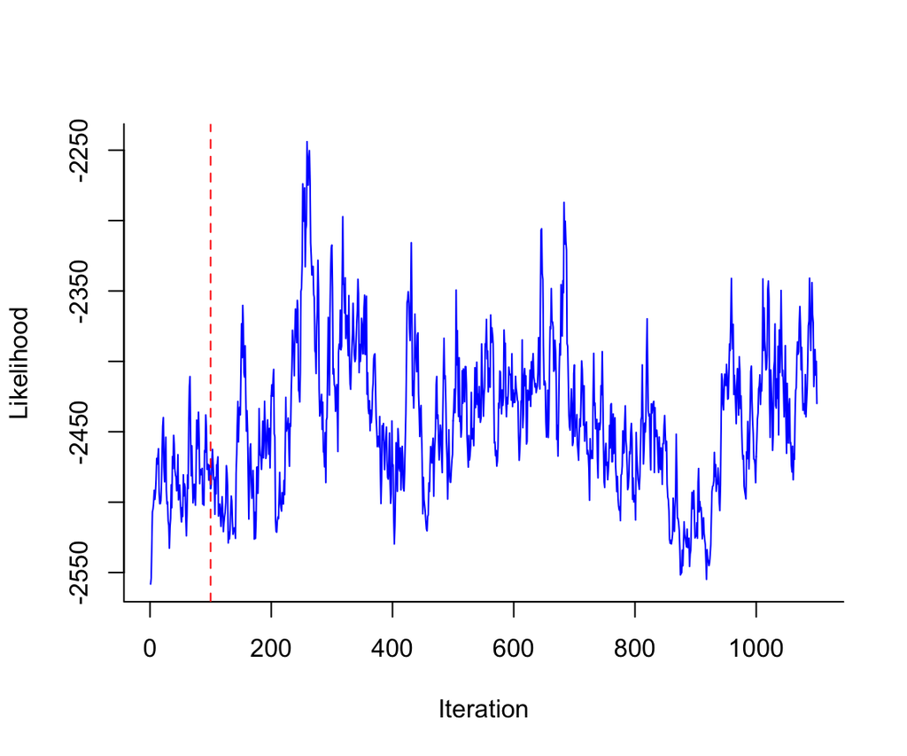

```r
plot_lik(quick_chain, bty="L")
```

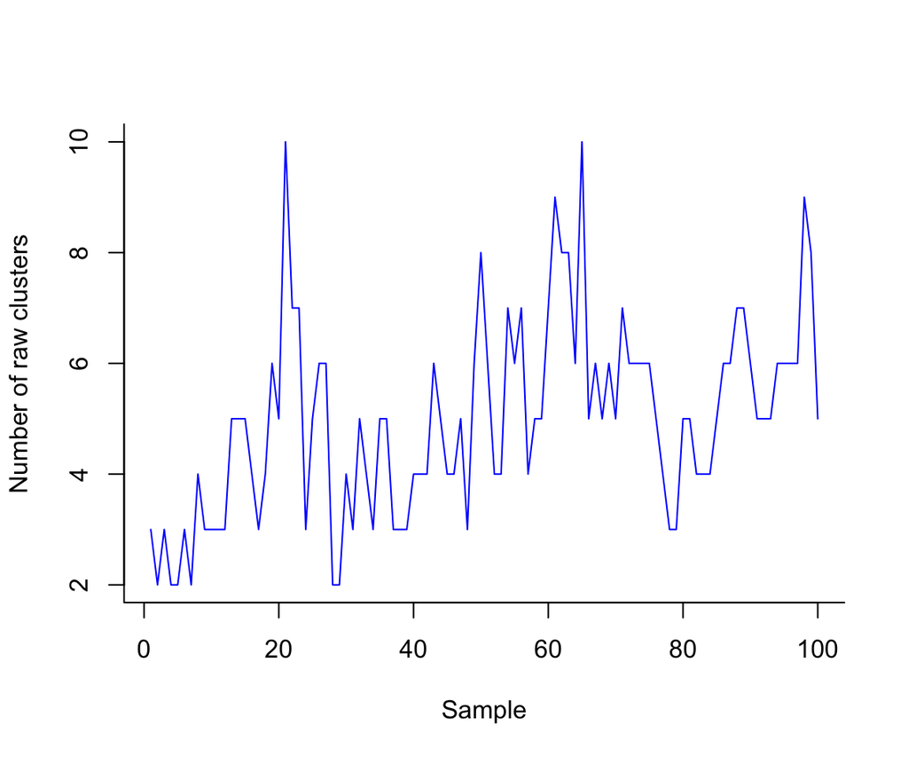

```r
plot_numcluster(quick_chain, bty="L")
```

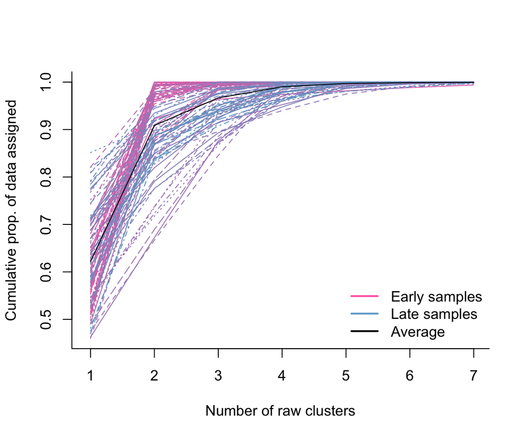

```r
plot_data_assigned(quick_chain, bty="L")
```

To extend the burn-in time post hoc (and consequently reduce the number of posterior samples included), use the function `cull_posterior_samples()`. Here, we cull the first 20 posterior samples and effectively extend the burn-in time to 300 iterations. Could then re-plot the diagnostic plots as above and see the change.

```r
quick_chain_v2 <- cull_posterior_samples(quick_chain, ncull=20)
quick_chain_v2
```

```
## Object of class hdpSampleChain
##  Random seed: 1234
##  Burn-in iters: 300
##  Posterior samples: 80
##  Iters b/w samples: 10
##  Conparam moves per iter: 1
##  Tabulate raw cluster number across samples:
##  2  3  4  5  6  7  8  9 10
##  2  9 14 19 20  8  4  2  2
##  Components: NO. Run hdp_extract_components
##  ----------
##  Final hdpState:
## Object of class hdpState
##  Number of DP nodes: 11
##  Index of parent DP: 0 1 1 1 1 1 1 1 1 1 ...
##  Number of data items per DP: 0 598 71 49 40 284 25 129 110 42 ...
##  Index of conparam per DP: 1 1 1 1 1 1 1 1 1 1 ...
##  Conparam hyperparameters and current value:
##            Shape Rate     Value
## Conparam 1     1    1 0.9198171
##  Number of data categories: 6
##  Number of clusters: 5
##  Initialised with 2 clusters, using random seed 5074783
```

## Extract components from hdpSampleChain

The raw cluster assignments are not a particularly useful description of the dataset because the number of raw clusters varies across posterior samples, and some raw clusters may be very small (e.g. one data item in its own cluster), or have very similar distributions across data categories (effectively describing one underlying process twice).

To provide a more useful summary of the posterior samples, the raw clusters are consolidated into components (constant number across posterior samples).

For a `hdpSampleChain` object, the `hdp_extract_components()` function matches up the clusters across posterior samples and groups them into components such that:

- at least `prop.ex` proportion of data items are assigned to a component (default 0.97), and
- components are merged if their cosine similarity is above `cos.merge` (default 0.90).

```r
quick_chain_v2 <- hdp_extract_components(quick_chain_v2)
quick_chain_v2
```

```
## Object of class hdpSampleChain
##  Random seed: 1234
##  Burn-in iters: 300
##  Posterior samples: 80
##  Iters b/w samples: 10
##  Conparam moves per iter: 1
##  Tabulate raw cluster number across samples:
##  2  3  4  5  6  7  8  9 10
##  2  9 14 19 20  8  4  2  2
##  Components: YES. Prop of data explained > 0.97  Merge if cosine sim > 0.9
##  Component number: 2
##  ----------
##  Final hdpState:
## Object of class hdpState
##  Number of DP nodes: 11
##  Index of parent DP: 0 1 1 1 1 1 1 1 1 1 ...
##  Number of data items per DP: 0 598 71 49 40 284 25 129 110 42 ...
##  Index of conparam per DP: 1 1 1 1 1 1 1 1 1 1 ...
##  Conparam hyperparameters and current value:
##            Shape Rate     Value
## Conparam 1     1    1 0.9198171
##  Number of data categories: 6
##  Number of clusters: 5
##  Initialised with 2 clusters, using random seed 5074783
```

Note that `quick_chain_v2` now includes component information, using two components to explain at least 97% of the dataset.

The following plot shows the number of data items assigned to each component in each posterior sample.

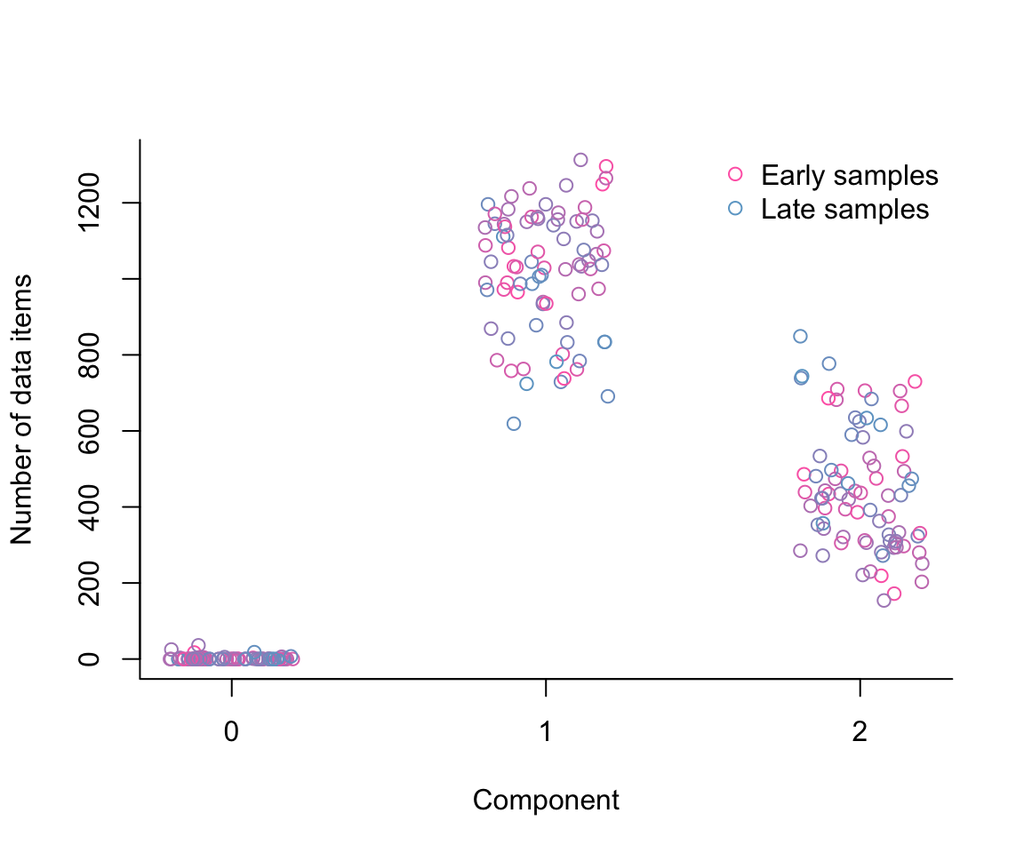

```r
plot_comp_size(quick_chain_v2, bty="L", lab=c(3, 5, 7))
```

The following plot shows the mean distribution of data categories for each component, and the 95% credibility intervals (thin black lines). See `?plot_comp_distn` for more options.

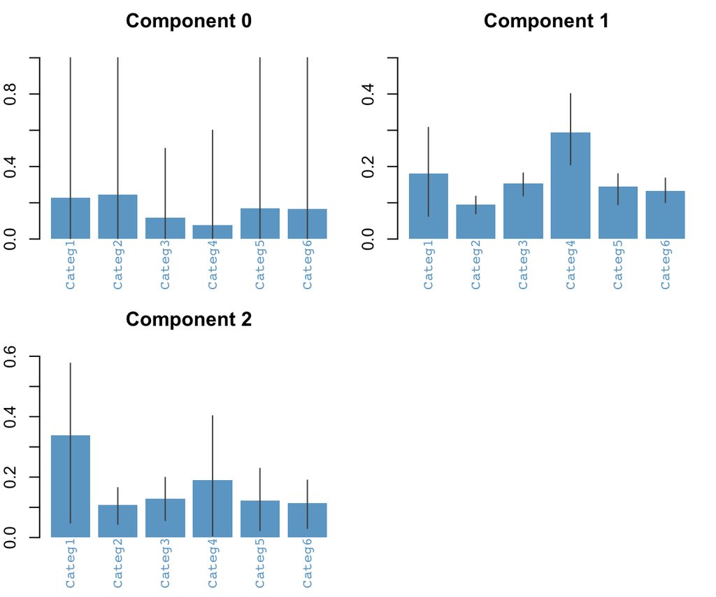

```r
par(mfrow=c(2,2), mar=c(3, 2, 2, 1))
plot_comp_distn(quick_chain_v2, cat_names=paste0("Categ", 1:6), col="skyblue3")
```

The following plots show the mean distribution of components at each specified DP node. See `?plot_dp_comp_exposure` for more options.

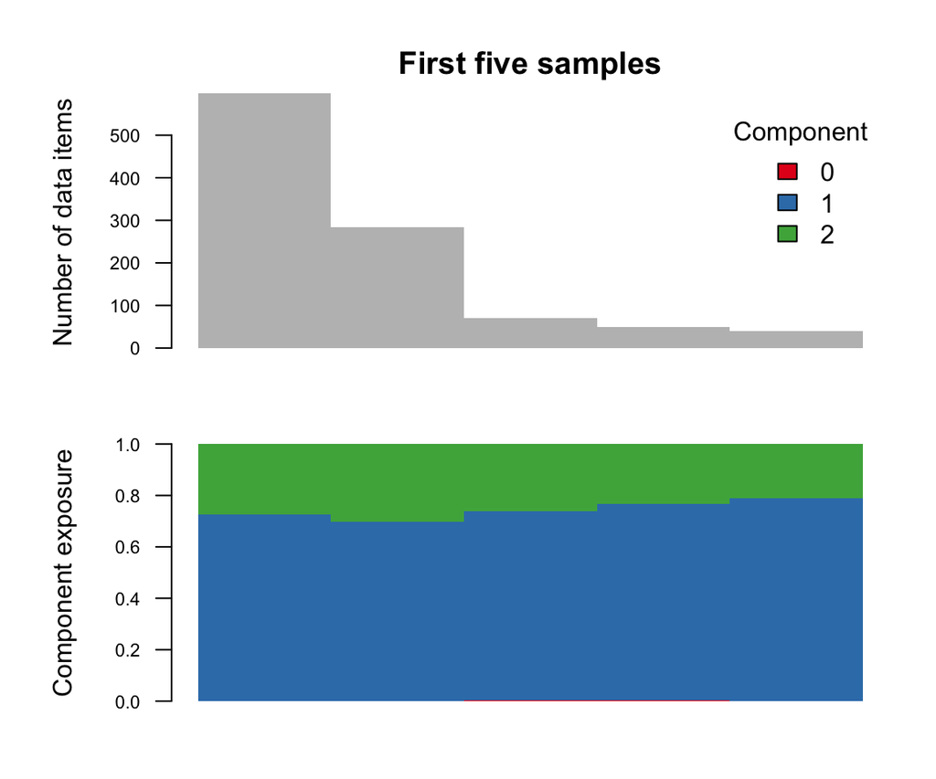

```r
plot_dp_comp_exposure(quick_chain_v2, dpindices=2:6, main_text="First five samples",
                      col=RColorBrewer::brewer.pal(3, "Set1"))
```

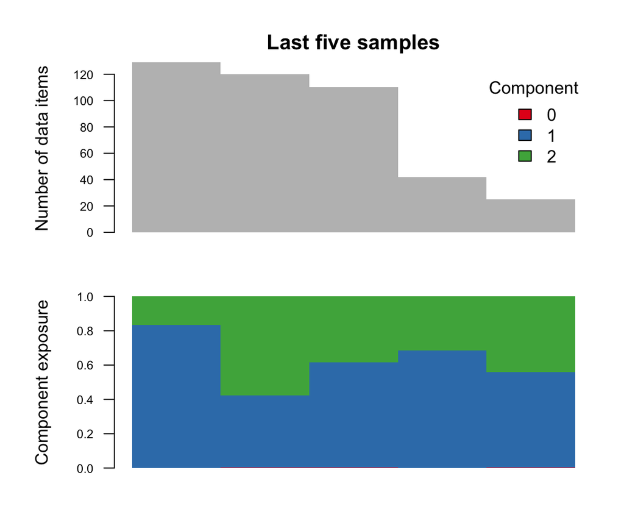

```r
plot_dp_comp_exposure(quick_chain_v2, dpindices=7:11, main_text="Last five samples",
                      col=RColorBrewer::brewer.pal(3, "Set1"))
```

Note that posterior samples collected off just one finite chain are somewhat correlated with each other, and the variance of the output statistics will tend to be underestimated. This problem is redressed in the next example by using multiple independent sampling chains.

# Customised HDP structure

## Initialise hdpState object via hdp_init and friends

Use `hdp_init()` to initialise a custom HDP structure by specifying a number of starting nodes, their parent relationships, the parameters (pseudocounts) of the base distribution, and a set of hyperparameters for the gamma priors over one or more concentration parameters.

```r
my_hdp <- hdp_init(ppindex=c(0, 1, 1),
                   cpindex=c(1, 2, 2),
                   hh=rep(1, 6),
                   alphaa=rep(2, 2),
                   alphab=rep(0.5, 2))
my_hdp
```

```
## Object of class hdpState
##  Number of DP nodes: 3
##  Index of parent DP: 0 1 1 ...
##  Number of data items per DP: 0 0 0 ...
##  Index of conparam per DP: 1 2 2 ...
##  Conparam hyperparameters and current value:
##            Shape Rate Value
## Conparam 1     2  0.5     4
## Conparam 2     2  0.5     4
##  Number of data categories: 6
##  Number of clusters: 0
```

Further DP nodes can be added to the structure via `hdp_adddp()`, and further concentration parameters can be added via `hdp_addconparam()`.

Next, we add two more concentration parameters, and ten further DP nodes (five children per parent).

```r
my_hdp <- hdp_addconparam(my_hdp,
                          alphaa=rep(2, 2),
                          alphab=rep(0.5, 2))
my_hdp <- hdp_adddp(my_hdp,
                    numdp=10,
                    ppindex=rep(2:3, each=5),
                    cpindex=rep(3:4, each=5))
my_hdp
```

```
## Object of class hdpState
##  Number of DP nodes: 13
##  Index of parent DP: 0 1 1 2 2 2 2 2 3 3 ...
##  Number of data items per DP: 0 0 0 0 0 0 0 0 0 0 ...
##  Index of conparam per DP: 1 2 2 3 3 3 3 3 4 4 ...
##  Conparam hyperparameters and current value:
##            Shape Rate Value
## Conparam 1     2  0.5     4
## Conparam 2     2  0.5     4
## Conparam 3     2  0.5     4
## Conparam 4     2  0.5     4
##  Number of data categories: 6
##  Number of clusters: 0
```

Data is assigned via `hdp_setdata()`, with one row of data assigned to each of the DP nodes specified.

```r
my_hdp <- hdp_setdata(my_hdp,
                      dpindex=4:13,
                      data=example_data_hdp)
my_hdp
```

```
## Object of class hdpState
##  Number of DP nodes: 13
##  Index of parent DP: 0 1 1 2 2 2 2 2 3 3 ...
##  Number of data items per DP: 0 0 0 598 71 49 40 284 25 129 ...
##  Index of conparam per DP: 1 2 2 3 3 3 3 3 4 4 ...
##  Conparam hyperparameters and current value:
##            Shape Rate Value
## Conparam 1     2  0.5     4
## Conparam 2     2  0.5     4
## Conparam 3     2  0.5     4
## Conparam 4     2  0.5     4
##  Number of data categories: 6
##  Number of clusters: 0
```

When initialised, the DP nodes are ‘heldout’ (not available for posterior sampling). Use `dp_activate()` to activate them and specify the number of starting clusters.

```r
my_hdp <- dp_activate(my_hdp,
                      dpindex=1:13,
                      initcc=2,
                      seed=5678)
my_hdp
```

```
## Object of class hdpState
##  Number of DP nodes: 13
##  Index of parent DP: 0 1 1 2 2 2 2 2 3 3 ...
##  Number of data items per DP: 0 0 0 598 71 49 40 284 25 129 ...
##  Index of conparam per DP: 1 2 2 3 3 3 3 3 4 4 ...
##  Conparam hyperparameters and current value:
##            Shape Rate Value
## Conparam 1     2  0.5     4
## Conparam 2     2  0.5     4
## Conparam 3     2  0.5     4
## Conparam 4     2  0.5     4
##  Number of data categories: 6
##  Number of clusters: 2
##  Initialised with 2 clusters, using random seed 5678
```

Now the `hdpState` object is ready for posterior sampling!

## Run multiple posterior sampling chains

Run four independent posterior sampling chains, and use `hdp_multi_chain()` to store in a `hdpSampleMulti` object.

```r
chlist <- vector("list", 4)

for (i in 1:4){
  chlist[[i]] <- hdp_posterior(my_hdp,
                               burnin=1000,
                               n=50,
                               space=50,
                               cpiter=3,
                               seed=i*1000)
}
```

```
## [1] "1000 burn-in iterations in 0.0 mins"
## [1] "1000 burn-in iterations in 0.0 mins"
## [1] "1000 burn-in iterations in 0.0 mins"
## [1] "1000 burn-in iterations in 0.0 mins"
```

```r
chlist[1:2]
```

```
## [[1]]
## Object of class hdpSampleChain
##  Random seed: 1000
##  Burn-in iters: 1000
##  Posterior samples: 50
##  Iters b/w samples: 50
##  Conparam moves per iter: 3
##  Tabulate raw cluster number across samples:
##  2  3  4  5  6  7  8  9 10 11
##  3  8  9  4  6  6  5  6  1  2
##  Components: NO. Run hdp_extract_components
##  ----------
##  Final hdpState:
## Object of class hdpState
##  Number of DP nodes: 13
##  Index of parent DP: 0 1 1 2 2 2 2 2 3 3 ...
##  Number of data items per DP: 0 0 0 598 71 49 40 284 25 129 ...
##  Index of conparam per DP: 1 2 2 3 3 3 3 3 4 4 ...
##  Conparam hyperparameters and current value:
##            Shape Rate    Value
## Conparam 1     2  0.5 6.498712
## Conparam 2     2  0.5 5.269668
## Conparam 3     2  0.5 3.489341
## Conparam 4     2  0.5 5.182761
##  Number of data categories: 6
##  Number of clusters: 8
##  Initialised with 2 clusters, using random seed 5678
##
## [[2]]
## Object of class hdpSampleChain
##  Random seed: 2000
##  Burn-in iters: 1000
##  Posterior samples: 50
##  Iters b/w samples: 50
##  Conparam moves per iter: 3
##  Tabulate raw cluster number across samples:
##  3  4  5  6  7  8  9 10 11 12 13 16 17 18
##  8 11  8  5  1  1  4  3  2  1  1  2  2  1
##  Components: NO. Run hdp_extract_components
##  ----------
##  Final hdpState:
## Object of class hdpState
##  Number of DP nodes: 13
##  Index of parent DP: 0 1 1 2 2 2 2 2 3 3 ...
##  Number of data items per DP: 0 0 0 598 71 49 40 284 25 129 ...
##  Index of conparam per DP: 1 2 2 3 3 3 3 3 4 4 ...
##  Conparam hyperparameters and current value:
##            Shape Rate     Value
## Conparam 1     2  0.5 2.9415814
## Conparam 2     2  0.5 2.7454925
## Conparam 3     2  0.5 3.4902809
## Conparam 4     2  0.5 0.9229537
##  Number of data categories: 6
##  Number of clusters: 3
##  Initialised with 2 clusters, using random seed 5678
```

```r
multi <- hdp_multi_chain(chlist)
multi
```

```
## Object of class hdpSampleMulti
##  Number of chains: 4
##  Total posterior samples: 200
##  Components: NO. Run hdp_extract_components
##  ----------
##  Final hdpState from first chain:
## Object of class hdpState
##  Number of DP nodes: 13
##  Index of parent DP: 0 1 1 2 2 2 2 2 3 3 ...
##  Number of data items per DP: 0 0 0 598 71 49 40 284 25 129 ...
##  Index of conparam per DP: 1 2 2 3 3 3 3 3 4 4 ...
##  Conparam hyperparameters and current value:
##            Shape Rate    Value
## Conparam 1     2  0.5 6.498712
## Conparam 2     2  0.5 5.269668
## Conparam 3     2  0.5 3.489341
## Conparam 4     2  0.5 5.182761
##  Number of data categories: 6
##  Number of clusters: 8
##  Initialised with 2 clusters, using random seed 5678
```

The constituent chains stored in a `hdpSampleMulti` object can be accessed via `chains()`.

## Diagnostic plots for hdpSampleMulti

To plot diagnostics for the constituent chains stored within a `hdpSampleMulti` object, use `lapply()` over `chains()`.

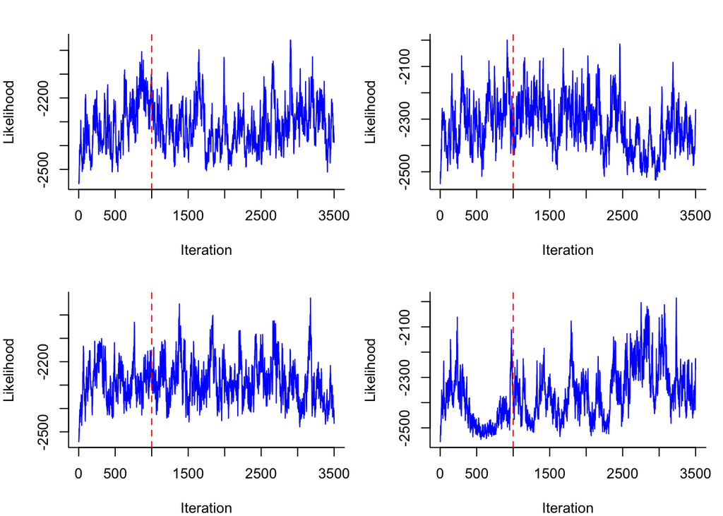

```r
par(mfrow=c(2,2), mar=c(4, 4, 2, 1))
p1 <- lapply(chains(multi), plot_lik, bty="L")
```

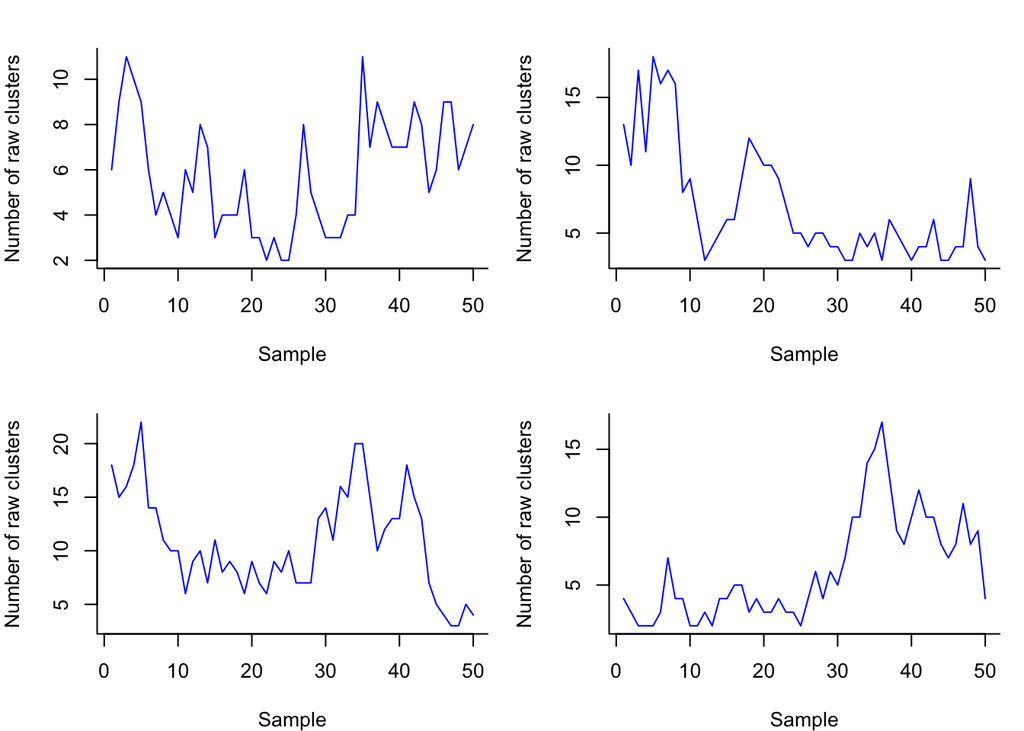

```r
p2 <- lapply(chains(multi), plot_numcluster, bty="L")
```

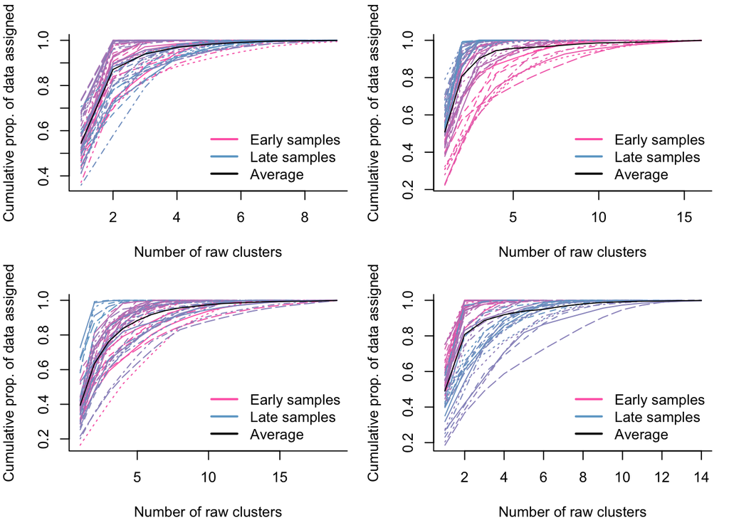

```r
p3 <- lapply(chains(multi), plot_data_assigned, bty="L")
```

Constituent chains can be dropped from a `hdpSampleMulti` object (e.g. `chains(multi) <- chains(multi)[-2]`) or have their burn-in time extended by dropping some initial samples (e.g. `chains(multi)[2] <- cull_posterior_samples(chains(multi)[2], 20)`).

## Extract components from hdpSampleMulti

For a `hdpSampleMulti` object, the `hdp_extract_components()` function matches clusters across posterior samples and chains, and groups them into components. Unlike the method for a `hdpSampleChain` object, there is no need to specify the `prop.ex` argument for proportion of dataset to explain. Rather, components are only included in the output if they have a consistent categorical distribution in all consituent sampling chains, and the resulting proportion of the data explained by these robustly identifiable components is reported in the output. Recall that data items not assigned to the main components are captured by the ‘zero component’ for noise and uncertainty.

```r
multi <- hdp_extract_components(multi)
multi
```

```
## Object of class hdpSampleMulti
##  Number of chains: 4
##  Total posterior samples: 200
##  Components: YES. Prop of data explained = 0.965  Merge if cosine sim > 0.9
##  Component number: 2
##  ----------
##  Final hdpState from first chain:
## Object of class hdpState
##  Number of DP nodes: 13
##  Index of parent DP: 0 1 1 2 2 2 2 2 3 3 ...
##  Number of data items per DP: 0 0 0 598 71 49 40 284 25 129 ...
##  Index of conparam per DP: 1 2 2 3 3 3 3 3 4 4 ...
##  Conparam hyperparameters and current value:
##            Shape Rate    Value
## Conparam 1     2  0.5 6.498712
## Conparam 2     2  0.5 5.269668
## Conparam 3     2  0.5 3.489341
## Conparam 4     2  0.5 5.182761
##  Number of data categories: 6
##  Number of clusters: 8
##  Initialised with 2 clusters, using random seed 5678
```

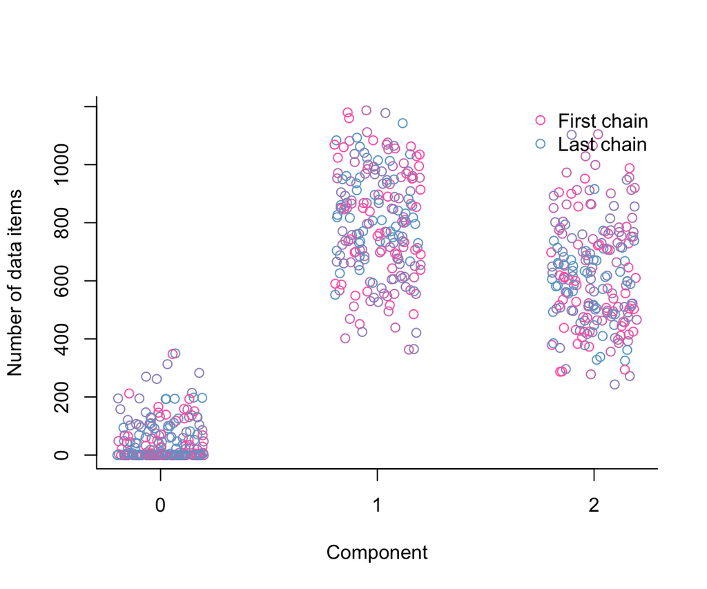

```r
plot_comp_size(multi, bty="L", lab=c(3, 5, 7))
```

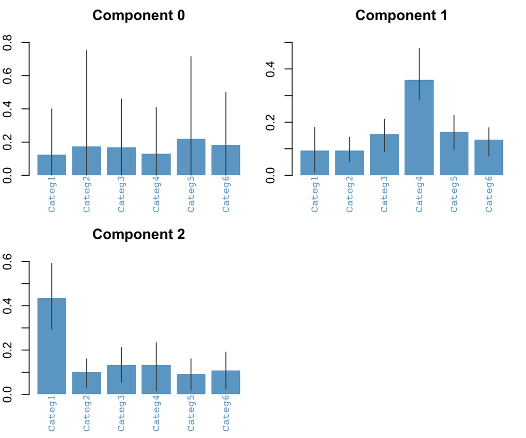

```r
par(mfrow=c(2,2), mar=c(3, 2, 2, 1))
plot_comp_distn(multi, cat_names=paste0("Categ", 1:6), col="skyblue3")

par(mfrow=c(1,1))
```

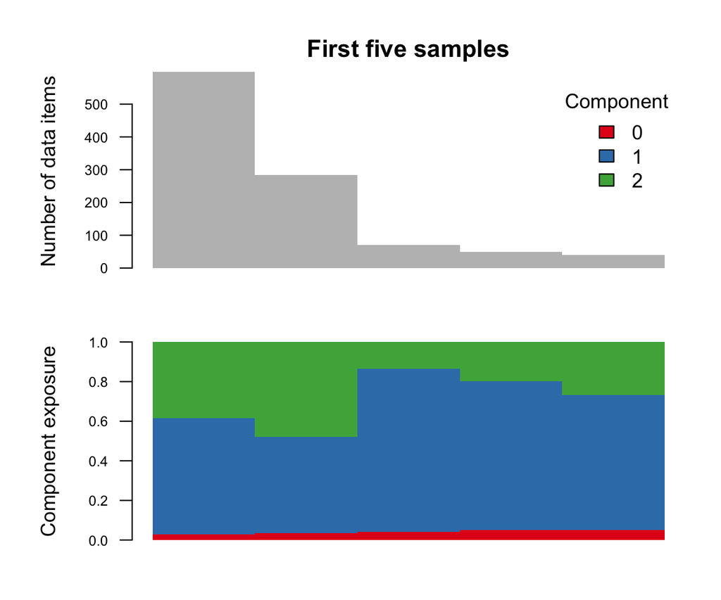

```r
plot_dp_comp_exposure(multi, dpindices=4:8, main_text="First five samples",
                      col=RColorBrewer::brewer.pal(3, "Set1"))
```

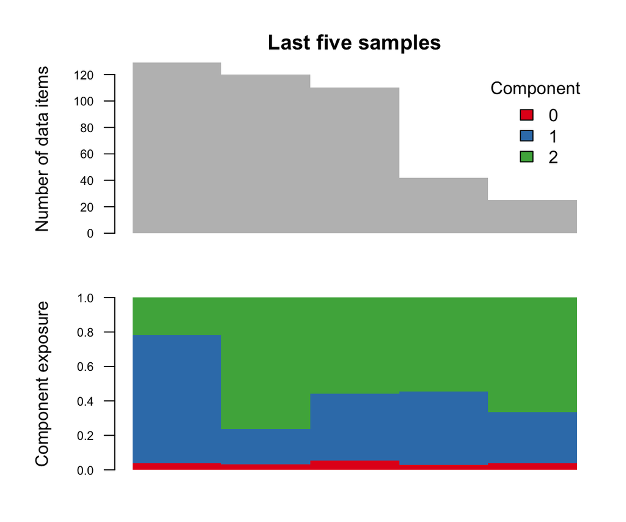

```r
plot_dp_comp_exposure(multi, dpindices=9:13, main_text="Last five samples",
                      col=RColorBrewer::brewer.pal(3, "Set1"))
```

# Access internal details of hdp object classes

For documentation on `hdpState` objects, see `class?hdpState`. Some slots of `hdpState` can be accessed like so:

```r
# number of data categories
numcateg(quick_hdp)
```

```
## [1] 6
```

```r
# number of DP nodes
numdp(quick_hdp)
```

```
## [1] 11
```

```r
# number of concentration parameters
numconparam(quick_hdp)
```

```
## [1] 1
```

```r
# 'base' distribution above the top DP node
base(quick_hdp)
```

```
## Object of class hdpBase
##  Number of data categories: 6
##  Prior over data categories: 1 1 1 1 1 ...
##  Number of clusters: 2
```

```r
# concentration parameter details
conparam(quick_hdp)
```

```
## [[1]]
## Object of class hdpConparam
##  Parameters of gamma prior: 1 1
##  Value: 1
##  Number of DPs using this concentration param: 11
```

```r
# DP node detail
dp(quick_hdp)[1:5]
```

```
## [[1]]
## Object of class hdpDP
##  Number of data items: 0
##  Number of child data tables in each cluster: 19 23 0
##
## [[2]]
## Object of class hdpDP
##  Number of data items: 598
##  Number of data items in each cluster: 284 314 0
##  Number of data items in each category: 130 59 86 158 84 81
##
## [[3]]
## Object of class hdpDP
##  Number of data items: 71
##  Number of data items in each cluster: 33 38 0
##  Number of data items in each category: 7 6 6 30 10 12
##
## [[4]]
## Object of class hdpDP
##  Number of data items: 49
##  Number of data items in each cluster: 26 23 0
##  Number of data items in each category: 5 8 7 15 6 8
##
## [[5]]
## Object of class hdpDP
##  Number of data items: 40
##  Number of data items in each cluster: 18 22 0
##  Number of data items in each category: 6 1 10 10 7 6
```

```r
# DP 'state' for each node
# 2 is activated (included in posterior sampling)
# 1 is frozen (conditioned on during posterior sampling)
# 0 is heldout (ignored during postering sampling)
dpstate(quick_hdp)
```

```
##  [1] 2 2 2 2 2 2 2 2 2 2 2
```

```r
# index of parent node for each node
ppindex(quick_hdp)
```

```
##  [1] 0 1 1 1 1 1 1 1 1 1 1
```

```r
# index of concentration parameter for each node
cpindex(quick_hdp)
```

```
##  [1] 1 1 1 1 1 1 1 1 1 1 1
```

For documentation on `hdpSampleChain` objects, see `class?hdpSampleChain`. Some slots of `hdpSampleChain` can be accessed like so:

```r
# random seed
hdp_seed(quick_chain)
```

```
## [1] 1234
```

```r
# settings of the posterior sampling chain
hdp_settings(quick_chain)
```

```
## $burnin
## [1] 100
##
## $n
## [1] 100
##
## $space
## [1] 10
##
## $cpiter
## [1] 1
```

```r
# instance of the hdpState object at the end of the chain
final_hdpState(quick_chain)
```

```
## Object of class hdpState
##  Number of DP nodes: 11
##  Index of parent DP: 0 1 1 1 1 1 1 1 1 1 ...
##  Number of data items per DP: 0 598 71 49 40 284 25 129 110 42 ...
##  Index of conparam per DP: 1 1 1 1 1 1 1 1 1 1 ...
##  Conparam hyperparameters and current value:
##            Shape Rate     Value
## Conparam 1     1    1 0.9198171
##  Number of data categories: 6
##  Number of clusters: 5
##  Initialised with 2 clusters, using random seed 5074783
```

```r
# data likelihood (given model) after every iteration
lik(quick_chain)[1:10]
```

```
##  [1] -2558.174 -2553.782 -2530.183 -2506.805 -2504.923 -2500.315 -2491.582
##  [8] -2498.022 -2493.036 -2484.162
```

```r
# number of raw clusters in each posterior sample
numcluster(quick_chain)[1:10]
```

```
##  [1] 3 2 3 2 2 3 2 4 3 3
```

```r
# concentration parameter values at each posterior sample
cp_values(quick_chain)[1:10]
```

```
##  [1] 0.4288431 0.2181880 0.4251175 0.1298855 0.2205072 0.8459244 0.4224820
##  [8] 0.7582503 0.8259397 0.5944517
```

```r
# List of matrices (one from each posterior sample) counting the category-cluster
# data assignment across all DP nodes. Number of rows is the number of
# categories (constant), and number of columns is the number of clusters
# in that posterior sample (variable).
clust_categ_counts(quick_chain)[1:3]
```

```
## [[1]]
##      [,1] [,2] [,3] [,4]
## [1,]  255   90    0    0
## [2,]   57   87    0    0
## [3,]   81  136    0    0
## [4,]  107  269    0    0
## [5,]   73  126    1    0
## [6,]   54  132    0    0
##
## [[2]]
##      [,1] [,2] [,3]
## [1,]  263   82    0
## [2,]   68   76    0
## [3,]  100  117    0
## [4,]  143  233    0
## [5,]  112   88    0
## [6,]   84  102    0
##
## [[3]]
##      [,1] [,2] [,3] [,4]
## [1,]  277   68    0    0
## [2,]   79   65    0    0
## [3,]  107  106    4    0
## [4,]  198  178    0    0
## [5,]  112   87    1    0
## [6,]   94   92    0    0
```

```r
# List of matrices (one from each posterior sample) counting within-DP cluster
# assignment (aggregating across data categories). Number of rows is the number of
# DPs (constant), and number of columns is the number of clusters in that posterior sample (variable).
clust_dp_counts(quick_chain)[1:3]
```

```
## [[1]]
##       [,1] [,2] [,3] [,4]
##  [1,]   10   15    1    0
##  [2,]  226  372    0    0
##  [3,]    0   71    0    0
##  [4,]    0   49    0    0
##  [5,]    0   40    0    0
##  [6,]  164  120    0    0
##  [7,]   25    0    0    0
##  [8,]    0  129    0    0
##  [9,]   52   57    1    0
## [10,]   42    0    0    0
## [11,]  118    2    0    0
##
## [[2]]
```

[output cut: 26 more lines]

The consituent `hdpSampleChain` objects within a `hdpSampleMulti` object can be accessed via `chains()`.

```r
chlist <- chains(multi)
chlist[3:4]
```

```
## [[1]]
## Object of class hdpSampleChain
##  Random seed: 3000
##  Burn-in iters: 1000
##  Posterior samples: 50
##  Iters b/w samples: 50
##  Conparam moves per iter: 3
##  Tabulate raw cluster number across samples:
##  3  4  5  6  7  8  9 10 11 12 13 14 15 16 18 20 22
##  2  2  2  3  6  3  4  5  3  1  4  3  4  2  3  2  1
##  Components: YES. Prop of data explained > 0.999  Merge if cosine sim > 0.9
##  Component number: 7
##  ----------
##  Final hdpState:
## Object of class hdpState
##  Number of DP nodes: 13
##  Index of parent DP: 0 1 1 2 2 2 2 2 3 3 ...
##  Number of data items per DP: 0 0 0 598 71 49 40 284 25 129 ...
##  Index of conparam per DP: 1 2 2 3 3 3 3 3 4 4 ...
##  Conparam hyperparameters and current value:
##            Shape Rate    Value
## Conparam 1     2  0.5 1.487077
## Conparam 2     2  0.5 2.187826
## Conparam 3     2  0.5 4.428447
## Conparam 4     2  0.5 6.679831
##  Number of data categories: 6
##  Number of clusters: 4
##  Initialised with 2 clusters, using random seed 5678
##
## [[2]]
## Object of class hdpSampleChain
##  Random seed: 4000
##  Burn-in iters: 1000
##  Posterior samples: 50
##  Iters b/w samples: 50
##  Conparam moves per iter: 3
##  Tabulate raw cluster number across samples:
##  2  3  4  5  6  7  8  9 10 11 12 13 14 15 17
##  7  8 10  3  2  3  4  2  5  1  1  1  1  1  1
##  Components: YES. Prop of data explained > 0.999  Merge if cosine sim > 0.9
##  Component number: 5
##  ----------
##  Final hdpState:
## Object of class hdpState
##  Number of DP nodes: 13
##  Index of parent DP: 0 1 1 2 2 2 2 2 3 3 ...
##  Number of data items per DP: 0 0 0 598 71 49 40 284 25 129 ...
##  Index of conparam per DP: 1 2 2 3 3 3 3 3 4 4 ...
##  Conparam hyperparameters and current value:
##            Shape Rate      Value
## Conparam 1     2  0.5  1.5825367
## Conparam 2     2  0.5 11.7573333
## Conparam 3     2  0.5  7.8397475
## Conparam 4     2  0.5  0.8309675
##  Number of data categories: 6
##  Number of clusters: 4
##  Initialised with 2 clusters, using random seed 5678
```

Accessors for the component summary stats are the same for `hdpSampleChain` and `hdpSampleMulti` objects.

```r
# List of matrices (one for each component) counting the sample-category data
# assignment across all DP nodes. Number of rows is the number of posterior samples,
# and number of columns is the number of data categories.
comp_categ_counts(multi)[[2]][1:10,]
```

```
##        1  2   3   4   5   6
##  [1,] 68 73 102 254  79  67
##  [2,] 23 57 126 309 104  85
##  [3,] 70 64 142 276 102  53
##  [4,] 38 46 101 225  54  85
##  [5,]  3 37  70 203  67 105
##  [6,] 20 81  99 223 137  78
##  [7,] 37 45 112 240 116  13
##  [8,] 35 54  77 303 139  90
##  [9,] 98 58 141 270 155 144
## [10,] 31 38  83 262  95  59
```

```r
# List of matrices (one for each DP) counting sample-component assignment
# (aggregating across data categories). Number of rows is the number of posterior
# samples, and number of columns is the number of components.
comp_dp_counts(multi)[[2]][1:10,]
```

```
##     0  1  2
## 1  21 68 39
## 2  15 45 28
## 3  32 95 53
## 4  24 50 18
## 5   0 35 51
## 6   6 50 30
## 7   0 39 53
## 8   3 65 34
## 9   0 31 18
## 10  0 24 32
```

```r
# List with elements "mean" and "cred.int", containing matrices with the mean
# (and lower/upper 95% credibility interval) over data categories for each component.
# Number of rows is the number of components, and number of columns is the
# number of data categories.
comp_categ_distn(multi)
```

```
## $mean
##            1         2         3         4         5         6
## 0 0.12526667 0.1737071 0.1693523 0.1296651 0.2201236 0.1818851
## 1 0.09338976 0.0939062 0.1546885 0.3588199 0.1639177 0.1352779
## 2 0.43580700 0.1009101 0.1324878 0.1316952 0.0904508 0.1086491
##
## $cred.int
## $cred.int$`0`
##        1    2     3     4     5   6
## [1,] 0.0 0.00 0.000 0.000 0.000 0.0
## [2,] 0.4 0.75 0.459 0.408 0.714 0.5
##
## $cred.int$`1`
##          1     2     3     4     5     6
## [1,] 0.011 0.052 0.089 0.284 0.098 0.073
## [2,] 0.180 0.143 0.211 0.478 0.226 0.179
##
## $cred.int$`2`
##          1     2     3     4     5     6
## [1,] 0.294 0.029 0.056 0.016 0.019 0.024
## [2,] 0.591 0.160 0.211 0.233 0.161 0.191
```

```r
# List with elements "mean" and "cred.int", containing matrices with the mean
# (and lower/upper 95% credibility interval) distribution over components for each DP.
# Number of rows is the number of DPs, and number of columns is the number of components.
comp_dp_distn(multi)$mean
```

```
##                0         1         2
##  [1,] 0.08509602 0.5006164 0.4142876
##  [2,] 0.04958450 0.6379830 0.3124325
##  [3,] 0.05086436 0.4208309 0.5283048
##  [4,] 0.02914716 0.5870401 0.3838127
##  [5,] 0.03978873 0.8243662 0.1358451
##  [6,] 0.05183673 0.7505102 0.1976531
##  [7,] 0.05200000 0.6818750 0.2661250
##  [8,] 0.03448944 0.4861268 0.4793838
##  [9,] 0.03860000 0.2964000 0.6650000
## [10,] 0.03767442 0.7436434 0.2186822
## [11,] 0.05331818 0.3893182 0.5573636
## [12,] 0.02714286 0.4264286 0.5464286
## [13,] 0.03070833 0.2057917 0.7635000
```

```r
comp_dp_distn(multi)$cred.int[4:7]
```

```
## [[1]]
##          0     1     2
## [1,] 0.000 0.311 0.156
## [2,] 0.149 0.839 0.692
##
## [[2]]
##          0     1    2
## [1,] 0.000 0.563 0.00
## [2,] 0.254 1.000 0.38
##
## [[3]]
##          0     1    2
## [1,] 0.000 0.429 0.00
## [2,] 0.286 1.000 0.51
##
## [[4]]
##        0   1   2
## [1,] 0.0 0.2 0.0
## [2,] 0.3 1.0 0.7
```

```
##  setting  value
##  version  R version 3.2.1 (2015-06-18)
##  system   x86_64, darwin10.8.0
##  ui       RStudio (0.98.1103)
##  language (EN)
##  collate  en_GB.UTF-8
##  tz       Europe/London
##  date     2015-10-05
```

```
## Packages ------------------------------------------------------------------
```

[output not shown]